# Lab6

Hope Hahn

2023-03-01

## Case Study: Eel Distribution Modeling

This week’s lab follows a project modeling the eel species Anguilla australis described by Elith et al. (2008). There are two data sets for this lab. You’ll use one for training and evaluating your model, and you’ll use your model to make predictions predictions on the other. Then you’ll compare your model’s performance to the model used by Elith et al.

## Data

Grab the training data sets (eel.model.data.csv, eel.eval.data.csv) from github here: https://github.com/MaRo406/eds-232-machine-learning/blob/main/data

```r
# read in data
eel_model <- read_csv(here::here("labs", "eel.model.data.csv")) %>%
    mutate(Angaus = as.factor(Angaus)) %>%
    select(-Site)

# read in eval data
eel_eval <- read_csv(here::here("labs", "eel.eval.data.csv")) %>%
    rename(Angaus = Angaus_obs) %>%
    mutate(Angaus = as.factor(Angaus))
```

### Split and Resample

Split the model data (eel.model.data.csv) into a training and test set, stratified by outcome score (Angaus). Use 10-fold CV to resample the training set.

```r
# split model data
eel_split <- initial_split(eel_model)
eel_train <- training(eel_split)
eel_test <- testing(eel_split)

# 10-fold CV
eel_cv <- eel_train %>%
    vfold_cv(v = 10)
```

### Preprocess

Create a recipe to prepare your data for the XGBoost model

```r
# create recipe
eel_recipe <- recipe(Angaus ~ ., data = eel_train) %>%
    step_dummy(all_nominal_predictors()) %>%
    step_normalize(all_numeric_predictors())
```

## Tuning XGBoost

### Tune Learning Rate

Following the XGBoost tuning strategy outlined in lecture, first we conduct tuning on just the learning rate parameter:

1. Create a model specification using {xgboost} for the estimation
- Only specify one parameter to tune()

```r
# model specification
eel_xgb <- boost_tree(learn_rate = tune()) %>%
    set_engine("xgboost") %>%
    set_mode("classification")

# set workflow
eel_wf <- workflow() %>%
    add_model(eel_xgb) %>%
    add_recipe(eel_recipe)
```

2. Set up a grid to tune your model by using a range of learning rate parameter values: expand.grid(learn_rate = seq(0.0001, 0.3, length.out = 30))
- Use appropriate metrics argument(s) - Computational efficiency becomes a factor as models get more complex and data get larger. Record the time it takes to run. Do this for each tuning phase you run.You could use {tictoc} or Sys.time().

```r
# tune hyperparameters
system.time(xgb_tune <- eel_wf %>%
    tune_grid(eel_cv, grid = expand.grid(learn_rate = seq(1e-04,
        0.3, length.out = 30))))
```

```
##    user  system elapsed
##   8.272   0.015   8.323
```

3. Show the performance of the best models and the estimates for the learning rate parameter values associated with each.

```r
# show the best model
show_best(xgb_tune)
```

```
## # A tibble: 5 × 7
##   learn_rate .metric .estimator  mean     n std_err .config
##        <dbl> <chr>   <chr>      <dbl> <int>   <dbl> <chr>
## 1      0.290 roc_auc binary     0.863    10  0.0148 Preprocessor1_Model29
## 2      0.279 roc_auc binary     0.862    10  0.0115 Preprocessor1_Model28
## 3      0.269 roc_auc binary     0.860    10  0.0125 Preprocessor1_Model27
## 4      0.228 roc_auc binary     0.859    10  0.0140 Preprocessor1_Model23
## 5      0.259 roc_auc binary     0.858    10  0.0131 Preprocessor1_Model26
```

```r
# select best learn rate
best1 <- select_best(xgb_tune)
lr_best <- best1$learn_rate
```

### Tune Tree Parameters

1. Create a new specification where you set the learning rate (which you already optimized) and tune the tree parameters.

```r
# model specification
eel_xgb2 <- boost_tree(learn_rate = lr_best, trees = 3000, tree_depth = tune(),
    min_n = tune(), loss_reduction = tune()) %>%
    set_engine("xgboost") %>%
    set_mode("classification")

# set workflow
eel_wf2 <- workflow() %>%
    add_model(eel_xgb2) %>%
    add_recipe(eel_recipe)
```

2. Set up a tuning grid. This time use grid_latin_hypercube() to get a representative sampling of the parameter space

```r
# tune hyperparameters
system.time(xgb_tune2 <- eel_wf2 %>%
    tune_grid(eel_cv, grid = grid_latin_hypercube(tree_depth(),
        min_n(), loss_reduction())))
```

```
##    user  system elapsed
##  20.611   0.090  20.778
```

3. Show the performance of the best models and the estimates for the tree parameter values associated with each.

```r
# show best models
show_best(xgb_tune2)
```

```
## # A tibble: 3 × 9
##   min_n tree_depth loss_reduction .metric .estimator  mean     n std_err .config
##   <int>      <int>          <dbl> <chr>   <chr>      <dbl> <int>   <dbl> <chr>
## 1    37         10   0.0000000631 roc_auc binary     0.836    10  0.0180 Prepro…
## 2    22         10   0.00199      roc_auc binary     0.826    10  0.0194 Prepro…
## 3    13          2   0.00654      roc_auc binary     0.798    10  0.0200 Prepro…
```

```r
# select best parameters
best2 <- select_best(xgb_tune2)
depth_best <- best2$tree_depth
min_n_best <- best2$min_n
loss_best <- best2$loss_reduction
```

### Tune Stochastic Parameters

1. Create a new specification where you set the learning rate and tree parameters (which you already optimized) and tune the stochastic parameters.

```r
# set model spec
eel_xgb3 <- boost_tree(learn_rate = lr_best, trees = 3000, tree_depth = depth_best,
    min_n = min_n_best, loss_reduction = loss_best, mtry = tune(),
    sample_size = tune()) %>%
    set_engine("xgboost") %>%
    set_mode("classification")

# set workflow
eel_wf3 <- workflow() %>%
    add_model(eel_xgb3) %>%
    add_recipe(eel_recipe)
```

2. Set up a tuning grid. Use grid_latin_hypercube() again.

```r
# tune parameters
system.time(xgb_tune3 <- eel_wf3 %>%
    tune_grid(eel_cv, grid_latin_hypercube(finalize(mtry(), eel_train),
        sample_size = sample_prop())))
```

```
##    user  system elapsed
##  43.843   0.261  44.340
```

3. Show the performance of the best models and the estimates for the tree parameter values associated with each.

```r
# show best models
show_best(xgb_tune3)
```

```
## # A tibble: 5 × 8
##    mtry sample_size .metric .estimator  mean     n std_err .config
##   <int>       <dbl> <chr>   <chr>      <dbl> <int>   <dbl> <chr>
## 1    10       0.893 roc_auc binary     0.837    10  0.0150 Preprocessor1_Model02
## 2    13       0.757 roc_auc binary     0.829    10  0.0169 Preprocessor1_Model04
## 3     1       0.937 roc_auc binary     0.829    10  0.0173 Preprocessor1_Model03
## 4    11       0.644 roc_auc binary     0.805    10  0.0161 Preprocessor1_Model08
## 5     6       0.581 roc_auc binary     0.785    10  0.0189 Preprocessor1_Model05
```

```r
# select best parameters
best3 <- select_best(xgb_tune3)
mtry_best <- best3$mtry
size_best <- best3$sample_size
```

## Finalize workflow and make final prediction

```r
# finalize workflow
xgb_final <- finalize_workflow(eel_wf3,
                               select_best(xgb_tune3, metric = "roc_auc"))

# fit model training data
train_fit_xgb <- fit(xgb_final, eel_train)

# predict with test data
test_predict_xgb <- predict(train_fit_xgb, eel_test) %>% #get prediction probabilities for test
  bind_cols(eel_test) #bind to testing column

# get accuracy
accuracy <- accuracy(test_predict_xgb, truth = Angaus, estimate = .pred_class)
```

1. How well did your model perform? What types of errors did it make?
- **The model’s accuracy was 0.804. The model had higher rates of type 2 errors.**

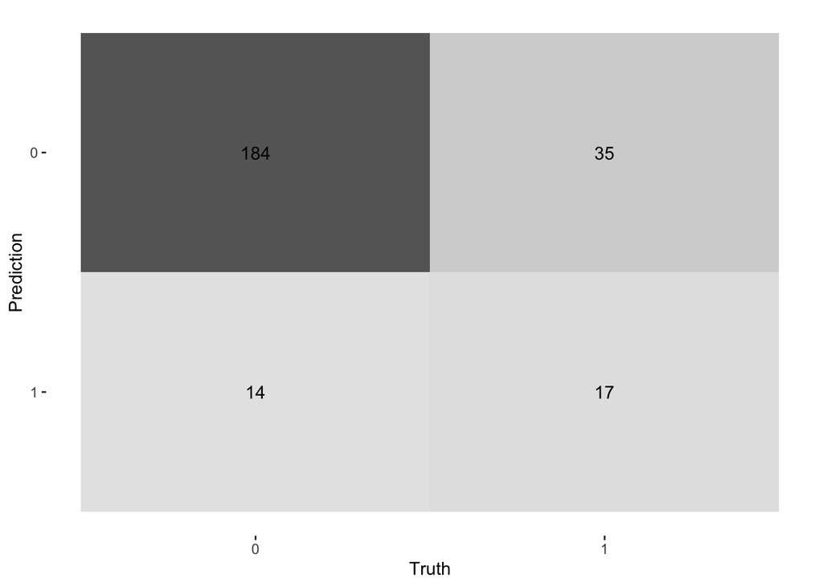

```r
# confusion matrix with heatmap
test_predict_xgb %>%
    conf_mat(truth = Angaus, estimate = .pred_class) %>%
    autoplot(type = "heatmap")
```

## Fit your model the evaluation data and compare performance

1. Now used your final model to predict on the other dataset (eval.data.csv)

```r
# prediction on eval data
eval_predict <- predict(train_fit_xgb, eel_eval) %>%
    bind_cols(eel_eval)  #bind to testing column
```

2. How does your model perform on this data?

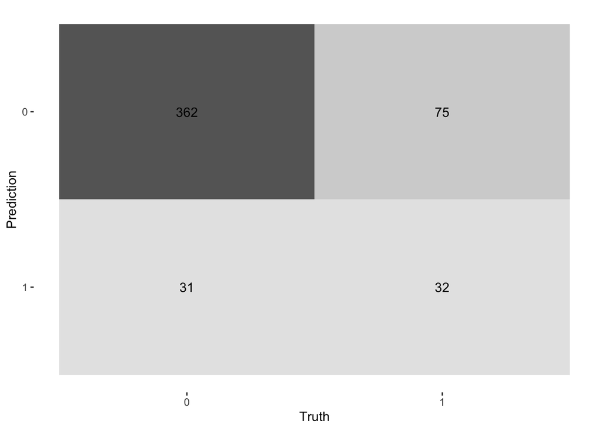

```r
# get accuracy on eval data
accuracy_eval <- accuracy(eval_predict, truth = Angaus, estimate = .pred_class)

# confusion matrix with heatmap
eval_predict %>%
    conf_mat(truth = Angaus, estimate = .pred_class) %>%
    autoplot(type = "heatmap")
```

- **The accuracy of the model on the eval data is 0.788. This is slightly lower than the accuracy on the test portion of the previous data. Type II errors are still the more common type of error.**
3. How do your results compare to those of Elith et al.?
- Use {vip} to compare variable importance
- What do your variable importance results tell you about the distribution of this eel species?

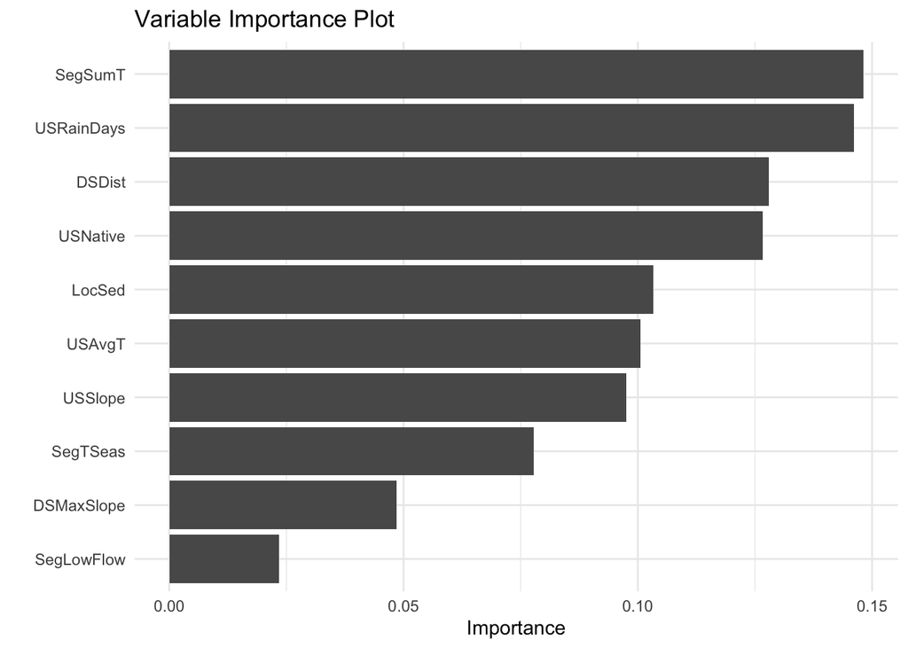

```r
vip::vip(train_fit_xgb) + theme_minimal() + labs(title = "Variable Importance Plot")
```

- **According to our model, the vip shows us that this eel species is dependent on Summer temperatures and the amount of rain days. It likely lives in areas with warmer temperatures. Additionally, it lives closer to coastal areas and is dependent on area of Indigenous forest. According to the Elith model, the Summer temperatures is the most important variable as well, so heat seems to be the main factor affecting this species distribution. Both models show that variables such as Winter temperature and segments of low flow do not determine the distribution as much. Overall, the variable importance results are not exactly the same, but they are very similar, with the order being very slightly different.**